# homework_8

Peter

2026-04-03

Sec 8.9 Exercises # 2,3,5,6,7,9,10,11,12

### Exercise 2

```r
mu_vals <- c(5, 10, 15, 20, 25, 30, 35)
prior   <- rep(1/7, 7)
y <- 28; sig <- 10

likelihood <- dnorm(y, mean = mu_vals, sd = sig)
posterior  <- (prior * likelihood) / sum(prior * likelihood)

data.frame(mu = mu_vals, prior = prior, likelihood = likelihood, posterior = posterior)
```

```
##   mu     prior  likelihood  posterior
## 1  5 0.1428571 0.002832704 0.01713652
## 2 10 0.1428571 0.007895016 0.04776111
## 3 15 0.1428571 0.017136859 0.10366989
## 4 20 0.1428571 0.028969155 0.17524969
## 5 25 0.1428571 0.038138782 0.23072159
## 6 30 0.1428571 0.039104269 0.23656234
## 7 35 0.1428571 0.031225393 0.18889886
```

```r
sum(posterior[mu_vals >= 30])
```

```
## [1] 0.4254612
```

The table above displays the discrete posterior distribution of mu for the given values. The probability that the mean is at least as large as 30 degrees is 0.4254612.

### Exercise 3

```r
library(ProbBayes)
# part a
normal.select(list(p = 0.25, x = 14), list(p = 0.8, x = 21))
```

```
## $mu
## [1] 17.11417
##
## $sigma
## [1] 4.617076
```

$\mu_0 = 17.11417$ and $\sigma_0 = 4.617076$

```r
qnorm(0.10, mean = 17.11417, sd = 4.617076)
```

```
## [1] 11.19715
```

The 0.10 quantile under the prior from part a is 11.19715. This is inconsistent with Sam’s 10.5.

```r
normal.select(list(p = 0.10, x = 10.5), list(p = 0.8, x = 21))
```

```
## $mu
## [1] 16.83782
##
## $sigma
## [1] 4.945429
```

We could instead use

$\mu_0 = 16.83782$ and $\sigma_0 = 4.945429$

to stay consistent with Sam’s beliefs.

### Exercise 5

```r
mun <- 17.4
sign <- 0.77

# part a
1 - pnorm(16.5, mun, sign)
```

```
## [1] 0.8787642
```

```r
# part b
pnorm(18, mun, sign) - pnorm(17, mun, sign)
```

```
## [1] 0.4803623
```

$P(\mu \geq 16.5 \mid y) = 0.8787642$

There is a 0.8787642 posterior probability that Federer’s mean time to serve is at least 16.5 seconds. So the statement is fairly likely.

$P(17 \leq \mu \leq 18 \mid y) = 0.4803623$

There is a 0.4803623 posterior probability that the mean time to serve is at least 17 and no more than 18 seconds. The statement has moderate posterior support.

### Exercise 6

```r
mun <- 17.4
sign <- 0.77

# part a
qnorm(c(0.01, 0.99), mun, sign)
```

```
## [1] 15.60871 19.19129
```

Credible interval for $\mu: (15.60871, 19.19129)$.

Since 16.5 is inside the interval, the hypothesis that $\mu = 16.5$ is consistent with the posterior and cannot be rejected at the 98% level.

### Exercise 7

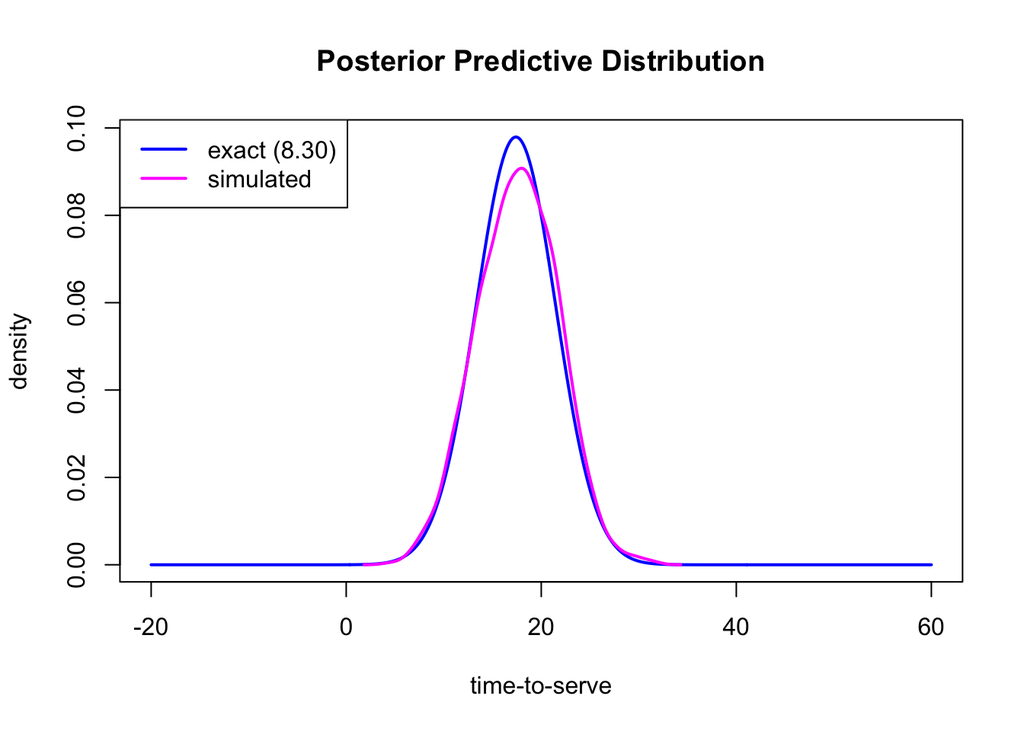

```r
mun  <- 17.4
sign <- 0.77
sig  <- 4
S    <- 1000

set.seed(123)

mu_sim <- rnorm(S, mean = mun, sd = sign)
y_pred <- rnorm(S, mean = mu_sim, sd = sig)

pred_sd <- sqrt(sig^2 + sign^2)

x <- seq(-20, 60, length = 500)
plot(x, dnorm(x, mun, pred_sd), type = 'l', col = "blue", lwd = 2,
     main = "Posterior Predictive Distribution",
     xlab = "time-to-serve", ylab = "density")
lines(density(y_pred), col = "magenta", lwd = 2)
legend("topleft", c("exact (8.30)", "simulated"),
       col = c("blue", "magenta"), lwd = 2)
```

```r
quantile(y_pred, c(0.05, 0.95))
```

```
##       5%      95%
## 10.76037 24.15775
```

The 90% prediction interval for a future time-to-serve is $(10.76037, 24.15775)$ seconds. This means we are 90% confident that Federer’s next single time-to-serve will fall in this range.

### Exercise 9

```r
normal.select(list(p = 0.25, x = 8), list(p = 0.75, x = 12))
```

```
## $mu
## [1] 10
##
## $sigma
## [1] 2.965204
```

$\mu_0= 10, \sigma_0=2.965204$

```r
fares <- c(7.5, 8.5, 9.5, 6.5, 7.0, 6.0, 7.0, 16.0, 8.0, 8.5,
           9.5, 13.5, 4.5, 8.5, 7.5, 13.0, 6.5, 9.5, 21.0, 6.5)
n <- length(fares)
ybar <- mean(fares)
sig <- 4

mu0 <- 10
sig0 <- 2.965204

prior <- c(mu0, sig0)
data  <- c(ybar, sig / sqrt(n))
normal_update(prior, data)
```

```
## [1] 9.2896343 0.8563181
```

$\pi(\mu \mid y) \sim N(9.2896343, 0.8563181)$

```r
mun  <- 9.2896343
sign <- 0.8563181

qnorm(c(0.05, 0.95), mun, sign)
```

```
## [1]  7.881116 10.698152
```

We are 90% confident that the mean taxi fare in New York City falls between $(7.881116, 10.698152)$.

### Exercise 10

```r
mu0_weak  <- 10
sig0_weak <- 100
```

Our week prior has: $\mu_0 = 10, \sigma_0 = 100$.

```r
fares <- c(7.5, 8.5, 9.5, 6.5, 7.0, 6.0, 7.0, 16.0, 8.0, 8.5,
           9.5, 13.5, 4.5, 8.5, 7.5, 13.0, 6.5, 9.5, 21.0, 6.5)
n <- length(fares)
ybar <- mean(fares)
sig <- 4

prior_weak <- c(mu0_weak, sig0_weak)
data       <- c(ybar, sig / sqrt(n))
normal_update(prior_weak, data)
```

```
## [1] 9.2250620 0.8943914
```

Due to our weak prior, we can see the posterior distribution is very similar to what we got in exercise 9:

$\pi(\mu \mid y) \sim N(9.2250620, 0.8943914)$

```r
mun_weak  <- 9.2250620
sign_weak <- 0.8943914

qnorm(c(0.05, 0.95), mun_weak, sign_weak)
```

```
## [1]  7.753919 10.696205
```

The 90% interval with the weakly informative prior is $(7.753919, 10.696205)$, compared to $(7.881116, 10.698152)$ from Exercise 9. The intervals are very similar, with $n = 20$ observations the data dominate and the choice of prior doesn’t have much influence on the posterior.

### Exercise 11

```r
mun  <- 9.2896343
sign <- 0.8563181
sig  <- 4

sim_fares <- function() {
  mu_draw <- rnorm(1, mean = mun, sd = sign)
  rnorm(20, mean = mu_draw, sd = sig)
}

sim_fares()
```

```
##  [1]  9.799290  6.685182 13.728449  9.548082  6.390466  1.623967  6.276814
##  [8] 17.035614  6.608489  5.507542 11.463329 10.616711 11.858055  7.739638
## [15] 13.342156  4.161103  8.656032  6.034977 11.574573  9.371566
```

```r
sim_max_fare <- function() {
  mu_draw <- rnorm(1, mean = mun, sd = sign)
  max(rnorm(20, mean = mu_draw, sd = sig))
}

max_fares <- replicate(1000, sim_max_fare())
```

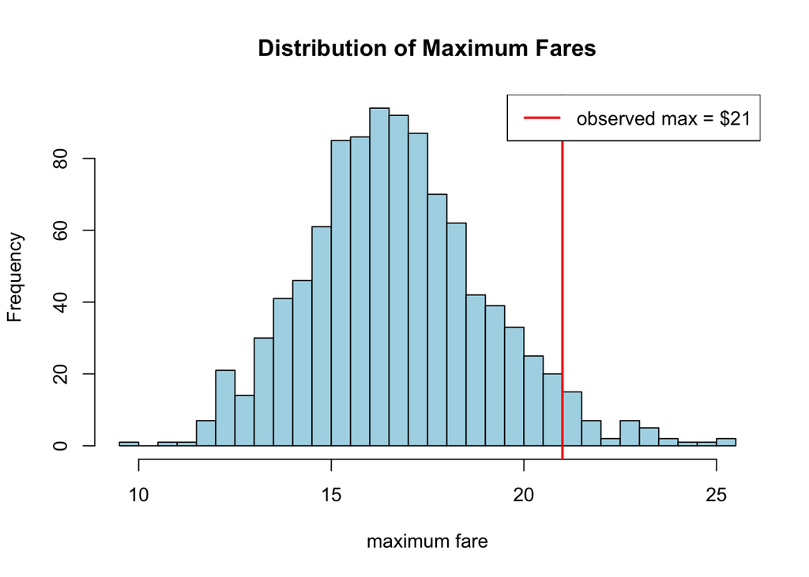

```r
hist(max_fares, breaks = 30, main = "Distribution of Maximum Fares",
     xlab = "maximum fare", col = "lightblue")
abline(v = 21, col = "red", lwd = 2)
legend("topright", "observed max = $21", col = "red", lwd = 2)
```

```r
mean(max_fares >= 21)
```

```
## [1] 0.042
```

The fare of $\$21$ is relatively large compared to the distribution, it falls in the right tail. About $4.2\%$ of the simulated max fares are at least $\$21$.

About $4.2\%$ of simulated maximum fares meet or exceed $\$21$, meaning the observed maximum is somewhat uncommon under the model. This could suggest the Normal model with $\sigma = 4$ may be slightly underestimating the spread of taxi fares, and a model with heavier tails or larger variance might be more appropriate.

### Exercise 12

```r
sleep <- c(9.0, 7.5, 7.0, 8.0, 5.0, 6.5, 8.5, 7.0, 9.0, 7.0, 5.5, 6.0, 8.5, 7.5)
n    <- length(sleep)
ybar <- mean(sleep)
sig  <- 1.5
mu0  <- 8
sig0 <- 1

prior <- c(mu0, sig0)
data  <- c(ybar, sig / sqrt(n))
normal_update(prior, data)
```

```
## [1] 7.3846154 0.3721042
```

```r
mun  <- 7.3846154
sign <- 0.3721042

qnorm(c(0.05, 0.95), mun, sign)
```

```
## [1] 6.772558 7.996672
```

The 90% credible interval for $\mu: (6.772558, 7.996672)$.

```r
pred_sd <- sqrt(sig^2 + sign^2)
qnorm(c(0.05, 0.95), mun, pred_sd)
```

```
## [1] 4.842552 9.926679
```

The $90\%$ prediction interval for a future student’s sleeping time is $(4.842552, 9.926679)$ hours. This is wider than the interval for $\mu$ in part b since it incorporates both uncertainty in $\mu$ and individual variability $\sigma = 1.5$.